# solvent-crystal_differences

```python
import pandas as pd
import numpy as np
import matplotlib.pyplot as plt
import seaborn as sns

%matplotlib inline
```

```python
from sklearn.preprocessing import StandardScaler
from scipy.stats import pearsonr, spearmanr
```

```python
sns.set_context('talk')
```

Рассматривать в дальнейшем будем подвыборку полиморфов, полученных из разных растворителей и проверим на ней вызывает ли бОльшая разница в свойствах растворителя, использованных для выращивания кристаллов двух полиморфных модификаций в рассматриваемой паре, бОльшие отличия в их кристаллической структуре. Для проверки вычислим коэффициенты корреляции между длинами векторов, соответствующими значениям разностей дескрипторов кристаллической структуры (13-мерный вектор) и разностей дескрипторов растворителя (62-мерный вектор). БОльшие различия в свойствах растворителя или кристалла в некоторой паре структур соответствуют бОльшей длине соответствующего вектора разностей дескрипторов, и наоборот.

```python
delta_crystal_solvent_df = pd.read_csv('row_difference_crystal-solvent_descriptors.txt', sep='\t', index_col=0)
```

Предварительно инвертируем значения дескриптора **match_15**. Это необходимо, чтобы бОльшие значения этого дескриптора соответствовали бОльшему отличию в молекулярных упаковах рассматриваемой пары структур. Т.е. удобнее для понимания было бы ещё и переименовать дескриптор в **mismatch_15**, но делать мы этого не будем.

```python
# revert values in order them to be high if structures are more dissimilar and low if they are more similar
delta_crystal_solvent_df['match_15'] = 15 - delta_crystal_solvent_df['match_15']
```

Рассмотрим для примера распределения значений разностей дескрипторов кристаллической структуры

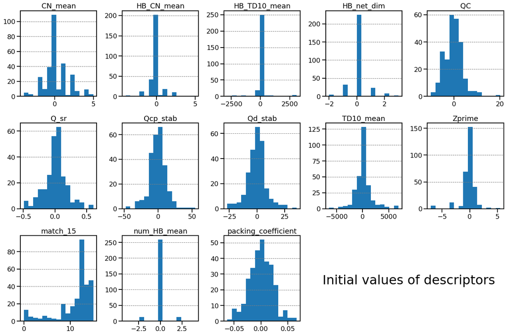

```python
ax = delta_crystal_solvent_df.iloc[:, :13].hist(bins=15, figsize=(18, 12), layout=(3, 5), grid=False)

for i in range(3):
    for x in ax[i]:
        x.grid(axis='y', color='gray', linestyle='--', linewidth=1)

plt.suptitle(t='Initial values of descriptors', x=.8, y=.19, fontsize=32)
plt.tight_layout()
```

Из-за разницы в масштабах значения разностей дескрипторов необходимо предварительно привести к единому масштабу

```python
ssc = StandardScaler(with_mean=False, with_std=True)

delta_crystal_solvent_df = delta_crystal_solvent_df.dropna(axis='index')
X_std = ssc.fit_transform(delta_crystal_solvent_df)
delta_crystal_solvent_df.iloc[:, :] = X_std
```

Проверим как изменились распределения

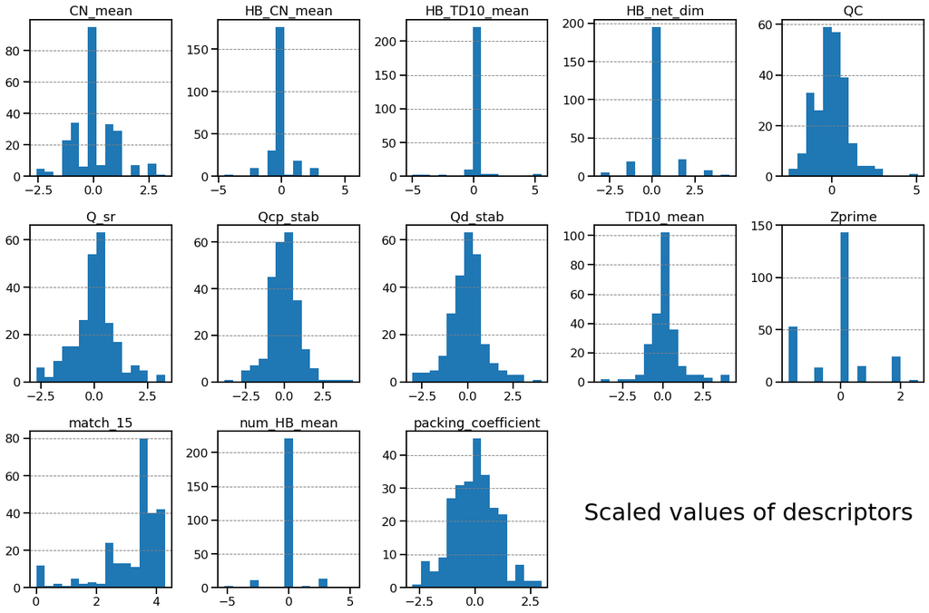

```python
ax = delta_crystal_solvent_df.iloc[:, :13].hist(bins=15, figsize=(18, 12), layout=(3, 5), grid=False)

for i in range(3):
    for x in ax[i]:
        x.grid(axis='y', color='gray', linestyle='--', linewidth=1)

plt.suptitle(t='Scaled values of descriptors', x=.8, y=.19, fontsize=32)
plt.tight_layout()
```

Теперь все распределения близки по масштабам

Создадим списки разностей дескрипторов кристаллической структуры и растворителей

```python
crystal_desc = ['Zprime', 'packing_coefficient', 'match_15', 'TD10_mean', 'CN_mean',
                'HB_net_dim', 'HB_TD10_mean', 'HB_CN_mean', 'num_HB_mean',
                'Qcp_stab', 'Q_sr', 'QC', 'Qd_stab']

solvent_desc = sorted(list(set(delta_crystal_solvent_df.columns.values) - set(crystal_desc)))
```

Рассчитаем длины векторов, соответсвующих разносятм дескрипторов кристаллической структуры (`'crystal_pair_dist'`) и растворителей (`'solvent_pair_dist'`)

```python
delta_crystal_solvent_df['crystal_pair_dist'] = np.linalg.norm(delta_crystal_solvent_df[crystal_desc], axis=1)
delta_crystal_solvent_df['solvent_pair_dist'] = np.linalg.norm(delta_crystal_solvent_df[solvent_desc], axis=1)
```

Посмотрим на распределения длин рассчитанных на предыдущем шаге векторов

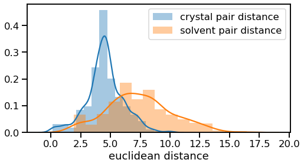

```python
fig, ax = plt.subplots(figsize=(8, 4))

sns.distplot(delta_crystal_solvent_df['crystal_pair_dist'], bins=15, ax=ax, label='crystal pair distance')
sns.distplot(delta_crystal_solvent_df['solvent_pair_dist'], bins=15, ax=ax, label='solvent pair distance')
ax.set_xlabel('euclidean distance')
ax.legend()
```

Рассчитаем коэффициенты корреляции между длинами указанных векторов и посмотрим на диаграмму рассеяния

```python
sp_rho = spearmanr(delta_crystal_solvent_df['crystal_pair_dist'], delta_crystal_solvent_df['solvent_pair_dist'])
pr_r = pearsonr(delta_crystal_solvent_df['crystal_pair_dist'], delta_crystal_solvent_df['solvent_pair_dist'])
```

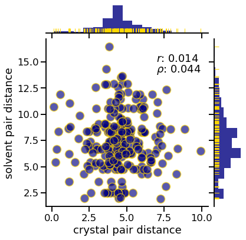

```python
g = sns.jointplot(x='crystal_pair_dist', y='solvent_pair_dist', data=delta_crystal_solvent_df,
                  color='navy',
                  marginal_kws=dict(bins=15, color='navy', rug=True,
                                    hist_kws=dict(alpha=.8),
                                    rug_kws=dict(height=.17, **dict(c='gold'))),
                  **dict(s=200, alpha=.65, edgecolor='gold'))
g.set_axis_labels(xlabel='crystal pair distance', ylabel='solvent pair distance')
g.ax_joint.text(x=7.0, y=15.0, s=r'$r$: {:.3f}'.format(pr_r[0]))
g.ax_joint.text(x=7.0, y=14.0, s=r'$\rho$: {:.3f}'.format(sp_rho[0]))
```

Как видим, нет никакой взаимосвязи между различиями в свойствах растворителей и различиями в кристаллической структуре полиморфных модификаций. *Этот результат можно интерпретировать таким образом, что в целом различия в структурах полиморфов не зависит от того насколько сильно отличаются растворители, использованные для выращивания кристаллов данных модификаций.*

Интерактивная версия визуализации полученной диаграммы рассеяния представлена ниже

```python
import os

import plotly
import plotly.express as px
import plotly.graph_objects as go
```

```python
CRYSTAL_SUBSETS = r'.\..\..\1_polymorphs_subset_retrieval'

different_solvent_poly = pd.read_excel(os.path.join(CRYSTAL_SUBSETS, 'different_solvent_polymorphs.xlsx'))
dsp_data = pd.read_csv(r'.\..\..\4_correlation search\DSC_full.txt', sep='\t')
```

```python
delta_crystal_solvent_data = delta_crystal_solvent_df[['crystal_pair_dist', 'solvent_pair_dist']].reset_index()
```

```python
def parse_data(string):

    p1, f1, p2, f2 = string.split('_')

    s1 = different_solvent_poly[different_solvent_poly['REFCODE-solvent'] == p1]['solvent'].values[0]
    s2 = different_solvent_poly[different_solvent_poly['REFCODE-solvent'] == p2]['solvent'].values[0]

    p1 = p1.split('-')[0]
    p2 = p2.split('-')[0]

    return [' {} / {}'.format(p1, p2),
            ' {} / {}'.format(f1.strip(')('), f2.strip(')(')),
            ' {} / {}'.format(s1, s2)]
```

```python
def hb_possible(string):
    p1, f1, p2, f2 = string.split('_')

    hbp1 = dsp_data[dsp_data['REFCODE-solvent'] == p1]['HB_present'].values[0]
    hbp2 = dsp_data[dsp_data['REFCODE-solvent'] == p2]['HB_present'].values[0]

    return ' True' if max(hbp1, hbp2) else ' False'
```

```python
def get_name(string):
    p1, f1, p2, f2 = string.split('_')

    name1 = dsp_data[dsp_data['REFCODE-solvent'] == p1]['[_chemical_name_systematic]'].values[0]
    name2 = dsp_data[dsp_data['REFCODE-solvent'] == p2]['[_chemical_name_systematic]'].values[0]

    return name1 if len(name1) < len(name2) else name2
```

```python
delta_crystal_solvent_data['data'] = delta_crystal_solvent_data['index'].apply(parse_data)

delta_crystal_solvent_data['refcodes'] = delta_crystal_solvent_data['data'].apply(lambda x: x[0])
delta_crystal_solvent_data['polymorphs'] = delta_crystal_solvent_data['data'].apply(lambda x: x[1])
delta_crystal_solvent_data['solvents'] = delta_crystal_solvent_data['data'].apply(lambda x: x[2])

delta_crystal_solvent_data['HB_present'] = delta_crystal_solvent_data['index'].apply(hb_possible)
delta_crystal_solvent_data['name'] = delta_crystal_solvent_data['index'].apply(get_name)
```

```python
fig = px.scatter(delta_crystal_solvent_data, x='crystal_pair_dist', y='solvent_pair_dist',
                 color='HB_present', color_discrete_map={' True': 'navy', ' False': 'darkred'},
                 hover_name='name',
                 hover_data=['refcodes', 'polymorphs', 'solvents'],
                 marginal_x='histogram',
                 marginal_y='histogram',
                 width=800, height=800
                )

fig.update_traces(marker=dict(size=16,
                              opacity=0.5,
                              line=dict(width=1.5, color='black')),
                  selector=dict(mode='markers')
                 )

fig.update_layout(
    xaxis=dict(title_text='crystal pair distance', title_font=dict(size=20), tickfont=dict(size=17)),
    yaxis=dict(title_text='solvent pair distance', title_font=dict(size=20), tickfont=dict(size=17))
                )

fig.show()
```

[interactive chart not shown]

На данной диаграмме рассеяния точки (пара кристаллических структур - полиморфные модификации одного соединения) дополнительно разделены на два класса в зависимости от наличия в структуре водородных связей. Для структур без водородных связей длины векторов разностей дескрипторов кристаллической структуры будут занижены из-за того, что как минимум для 4 дескрипторов значения их разностей всегда будут равны нулю. Данная диаграмма рассеяния позволяет рассмотреть эти два класса структур отдельно - можно убрать с диаграммы один из классов. При наведении на точку появляется информация о паре структур, которой она соответствует.